# Data Exploration mit Gapminder

# 3.9 Farben

Eigene Palette aus RColorBrewer statt der ggplot-Defaults. `Set2` ist qualitativ, also gedacht für Kategorien ohne Reihenfolge.

```r
library(RColorBrewer)
brewer.pal(5, "Set1")
```

```
## [1] "#E41A1C" "#377EB8" "#4DAF4A" "#984EA3" "#FF7F00"
```

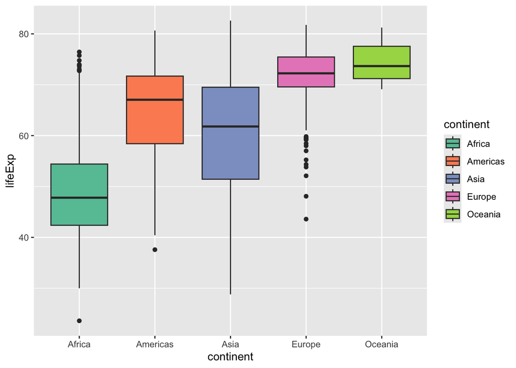

```r
ggplot(df, aes(x = continent, y = lifeExp, fill = continent)) +
  geom_boxplot() +
  scale_fill_brewer(palette = "Set2")
```

# 3.10 Heatmap

Im Buch: Gene × Samples. Bei mir mach ich Länder × Jahre mit lifeExp als Wert. Über alle Länder wird das riesig, deshalb nur Europa.

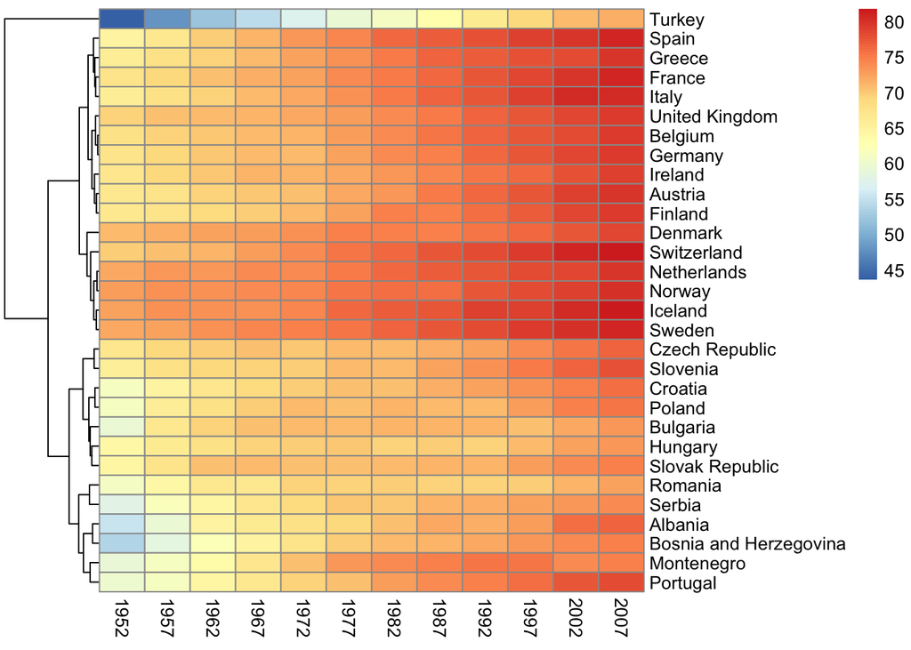

```r
library(pheatmap)
library(tidyr)

mat <- subset(df, continent == "Europe") |>
  pivot_wider(id_cols = country, names_from = year, values_from = lifeExp) |>
  tibble::column_to_rownames("country") |>
  as.matrix()

pheatmap(mat, cluster_cols = FALSE)
```

Spalten (Jahre) nicht clustern, damit die Reihenfolge chronologisch bleibt. Zeilen werden geclustert, dann landen ähnliche Länder nebeneinander.

# 3.11 Rang-Transformation

Zeigt schön, dass der scheinbare Zusammenhang teilweise nur an der Punktdichte liegt:

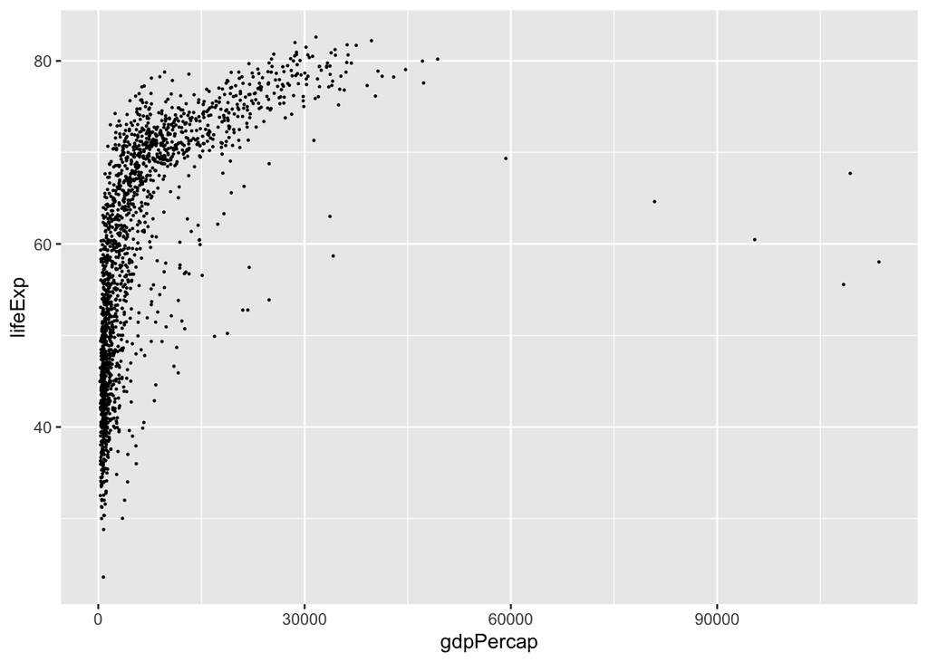

```r
ggplot(df, aes(x = gdpPercap, y = lifeExp)) + geom_point(size = 0.2)
```

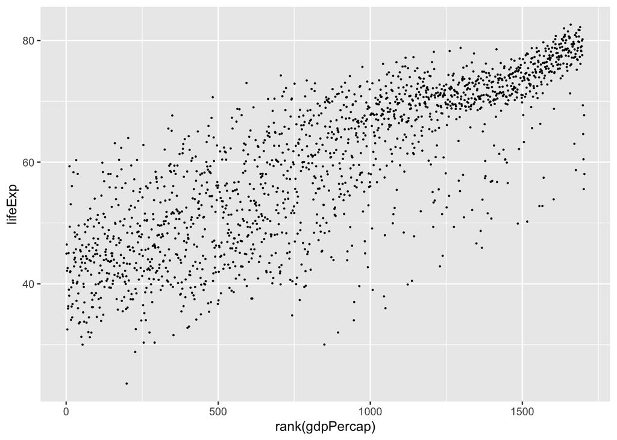

```r
ggplot(df, aes(x = rank(gdpPercap), y = lifeExp)) + geom_point(size = 0.2)
```

# Was nicht ging

Die Bioconductor-Teile aus dem Kapitel (`ExpressionSet`, `Biobase::exprs`, `AnnotationDbi::select`, `mouse4302.db`) lassen sich nicht übertragen, die hängen an den Microarray-Objekten und haben kein Gapminder-Gegenstück. Die Mathe-Symbol-Sachen aus 3.12 sind nicht datenabhängig, da kann man höchstens die `expression()`-Syntax übernehmen, z.B. `xlab(expression(log[10](gdpPercap)))`.